# Lab_05R

## Question 3

Use the `hclust()` function to build a hierarchical clustering tree for `df.new`, and use the basic `plot()` function to display the dendrogram. Try both complete and average linkage: which one makes for the best-looking output? (This should not be confused with: which one gives the best clustering result? Note: there is no “right” answer here; best-looking is in the eye of the statistical consultant.) Despite talking up the dendrogram in class, is this actually useful output here? Why or why not? If your client asked for a dendrogram, what step might you want to consider taking before providing one? (Note: when calling `plot()`, consider passing the argument `labels=FALSE` to remove the row numbers at the base of dendrogram.)

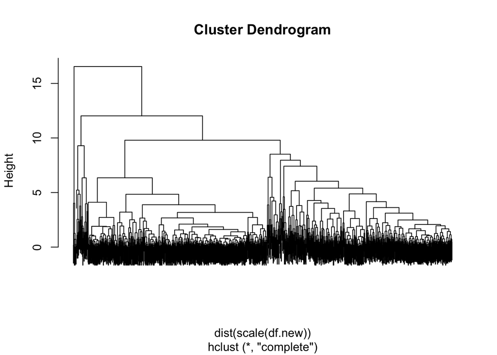

```r
# FILL ME IN
hc.out = hclust(dist(scale(df.new)),method="complete")  # we use the same data as we do for K-means
plot(hc.out,labels=FALSE)
```

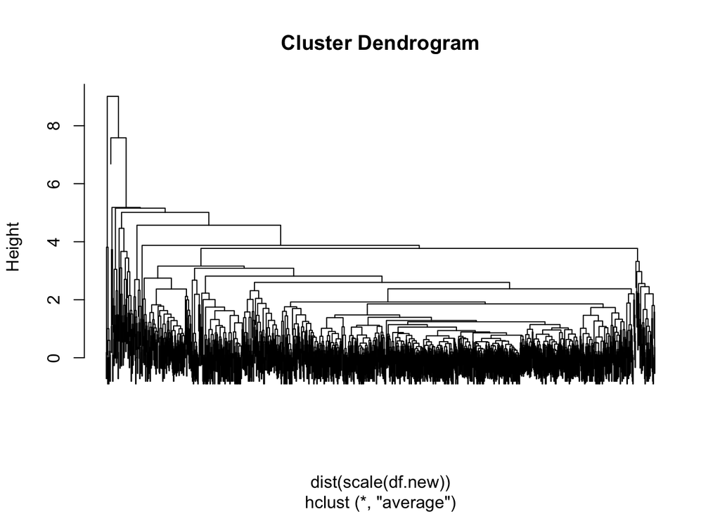

[output not shown]

```r
hc.out = hclust(dist(scale(df.new)),method="average")  # we use the same data as we do for K-means
plot(hc.out,labels=FALSE)
```